# Neural & Behavioral Modeling - Week 1 (Exercises)

by 張天瑋 b09705049@gmail.com

```python
%config IPCompleter.greedy=True
%matplotlib inline
import numpy as np
import matplotlib.pyplot as plt
import sympy as sym
from IPython.display import *
```

## 1 Party Simulation (5 points)

This is a model of a cocktail party. The men and women at the party form groups. A party-goer becomes uncomfortable and switches groups if their current group has too many members of the opposite sex.

### 1.1 Insert your codes to complete the simulation (2 points)

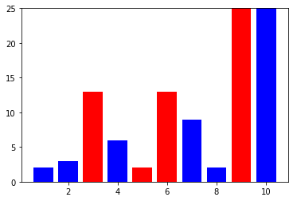

```python
# Model parameters:
Ngroups=10
Npeople=100
Tolerance=0.25 # tolerable propotion of the opposite sex

# Supporting functions:
class Person:
    def __init__(self, Ngroups):
        self.sex = np.random.randint(2) # 0=woman; 1=man
        self.Ngroups=Ngroups
        self.group = np.random.randint(Ngroups) # staying in which group?

    def leave(self):
        options=np.delete(np.arange(self.Ngroups),self.group) # except the current group
        self.group = int(np.random.choice(options,1)) # choosing a new group

def party_stats(people): # calculate the number of men & women in each group
    Npeople=len(people)
    sexes=[people[i].sex for i in range(Npeople)]
    groups=[people[i].group for i in range(Npeople)]
    counts=np.zeros((max(groups)+1,max(sexes)+1))
    proportions=counts.copy()
    for p in range(Npeople):
        counts[groups[p],sexes[p]]+=1
    men_plus_women=np.sum(counts,1) # number of men and women in each group
    men_plus_women[men_plus_women==0]=np.inf # to avoid "dividing by zeros later
    proportions[:,0]=counts[:,0]/men_plus_women # proportion of women in each group
    proportions[:,1]=counts[:,1]/men_plus_women # proportion of men in each group
    return counts, proportions # size=group*sex

def plot_party(counts):
    x=np.arange(len(counts))+1 # number of groups
    plt.clf() # clear previous figure
    plt.bar(x, counts[:,0], color = 'r') # women
    plt.bar(x, counts[:,1], color = 'b', bottom = counts[:,0]) # men on top of women in the plot
    display(plt.gcf()); clear_output(wait=True) # to allow dynamic plots

# Initialization:
people = [Person(Ngroups) for i in range(Npeople)] # assign each person to a group
Nhappy=0 # Number of happy people
iteration = 0
# Simulation:
while(Nhappy < Npeople): # Simulation stops when everyone is happy
    iteration += 1
    counts, proportions = party_stats(people)# size=group*sex
    # Plot results
    plot_party(counts)

    Nhappy=0 # recounting after a new move
    for i in range(Npeople):
        if proportions[people[i].group, people[i].sex] < (1 - Tolerance):
            people[i].leave()
        else :
            Nhappy += 1
```

### 1.2 Modify the three model parameters & discuss how each affects your simulations (2 points)

```python
def party(Ngroups, Npeople, Tolerance):
    people = [Person(Ngroups) for i in range(Npeople)] # assign each person to a group
    Nhappy = 0
    iteration = 0
    while(Nhappy < Npeople): # Simulation stops when everyone is happy
        iteration += 1
        counts, proportions = party_stats(people)# size=group*sex

        # Plot results
        plot_party(counts)

        Nhappy=0 # recounting after a new move
        for i in range(Npeople):
            if proportions[people[i].group, people[i].sex] < (1 - Tolerance):
                people[i].leave()
            else :
                Nhappy += 1
    print('iteration:' , iteration)
```

## Modify Ngroups

```
iteration: 20
Ngroup = 5
```

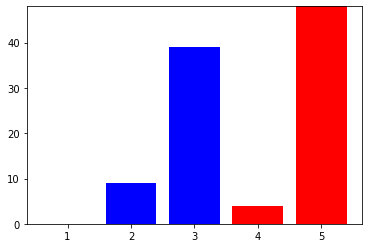

```python
party(5, 100, 0.25)
print('Ngroup = 5')
```

```
iteration: 12
Ngroup = 10
```

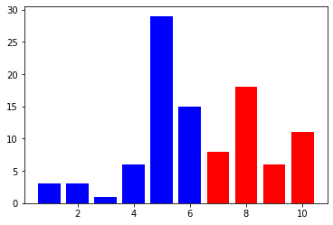

```python
party(10, 100, 0.25)
print('Ngroup = 10')
```

```
iteration: 7
Ngroup = 50
```

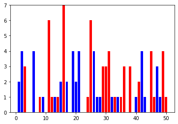

```python
party(50, 100, 0.25)
print('Ngroup = 50')
```

As the plots show, we can conclude that convergence only happens when male and female are in the differenct group(Because Tolerance < 0.5). And as the group number growth,the simulation take less iteration to converge.

## Modify Npeople

```
iteration: 4
Npeople = 10
```

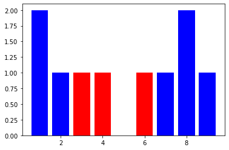

```python
party(10, 10, 0.25)
print('Npeople = 10')
```

```
iteration: 22
Npeople = 100
```

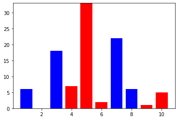

```python
party(10, 100, 0.25)
print('Npeople = 100')
```

```
iteration: 56
Npeople = 300
```

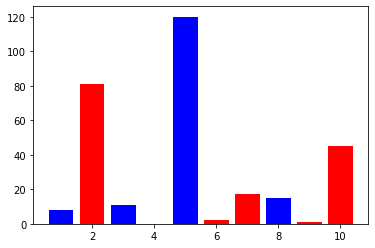

```python
party(10, 300, 0.25)
print('Npeople = 300')
```

As the plots show, we can conclude that convergence only happens when male and female are in the differenct group(Because Tolerance < 0.5). And as the people number growth,the simulation take more iteration to converge.

## Modify Tolerance

```
iteration: 9
Tolerance = 0.25
```

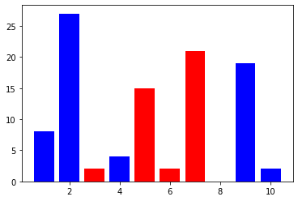

```python
party(10, 100, 0.25)
print('Tolerance = 0.25')
```

```
iteration: 6
Tolerance = 0.5
```

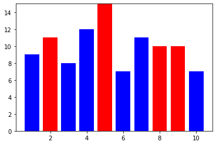

```python
party(10, 100, 0.5)
print('Tolerance = 0.5')
```

```
iteration: 2
Tolerance = 0.75
```

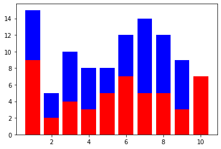

```python
party(10, 100, 0.75)
print('Tolerance = 0.75')
```

As the plots show, we can infer that when Tolerance < 0.5, male and female are seperated in different groups. While when Tolerance >= 0.5, there might be male and female in the same group. And since they are more likely to accept opposite gender people in their groups, the simulation seems like take less time to converge.

### 1.3 Discuss why the simulaiton leads to group polarization (1 point)

When Tolerance < 0.5 , the simulaiton leads to group polarization. If Tolerance < 0.5 , there are three case

1. The man proportions is larger than the tolerance value => all women in that group will leave.
2. The woman proportions is larger than the tolerance value => all men in that group will leave.
3. Both sex proportions is larger than the tolerance value => all people in that group will leave.

So after many iteration, there will only remain the group without any people or only one sex.

## 2 Understand Shunting Equation (5 points)

$\frac{dy}{dt}=-Ay+(B-y)*E-(y-C)*I$

### 2.1 Find its equilibrium by analytically solving $dy/dt=0$ (1 point)

Write your answer here with [LaTex](https://www.sharelatex.com/learn/Mathematical_expressions) formula

## $y(t) = \frac {B\times E+C\times I}{A+E+I}$

### 2.2 Use Euler integration to verify your answer in 2.1 with your own (A, B, C, E, I) constants (2 points)

Euler Integration: $dy/dt=f(t) \implies \frac{y(t2)-y(t1)}{\Delta t}=f(t) \implies y(t2)=y(t1)+\Delta t*f(t)$

```python
a,b,c,e,i,t = sym.symbols('A,B,C,E,I,t')
y = sym.Function('y')(t)
sym.dsolve(y.diff()+a*y-(b-y)*e+(y-c)*i) # solving dy/dt+Ay-(B-y)*E+(y-C)*I=0
```

$\displaystyle y{\left(t \right)} = \frac{B E}{A + E + I} + \frac{C I}{A + E + I} + C_{1} e^{- t \left(A + E + I\right)}$

$Let\ A = 1,B = 1, C = 1 , E = 1 , I = 1 ,C_1 = 1$

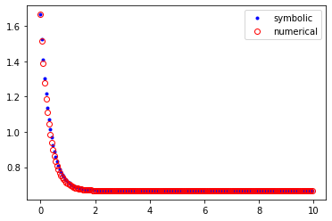

```python
# dy/dt = f(t) = -y + (1 - y) - (y - 1)=-3y + 2
dt=0.05
y=[5/3]# y(0) = 2/3 + 1
t=np.arange(0,10,dt)
for i in t:
    y1=y[-1] # the last element
    y2=y1+dt*(-3*y1 + 2) # Euler integration
    y.append(y2)
plt.plot(t,np.exp(-3*t)+ 2/3,'b.'); # true answer
plt.plot(t,y[0:-1],'ro',markerfacecolor='None') # approximation
plt.legend(['symbolic','numerical']);
```

### 2.3 Combining math & if-then controls in numerical integrations (2 points)

Use Euler integration to plot $dy/dt=-y(t)+E$ where $E=\begin{cases} 1 & \text{if } t<5\\ 0 & \text{if } t>5 \end{cases}$ for t=[0,10] & y(t=0)=0.

This is an example of time-varying rather than constant excitation.

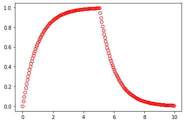

```python
dt=0.05
y=[0] # y(0) = 0
t=np.arange(0,10,dt)
for i in t:
    y1=y[-1] # the last element
    if i <= 5 :
        y2=y1+dt*(-y1 + 1) # Euler integration
    else :
        y2=y1+dt*(-y1) # Euler integration
    y.append(y2)
plt.plot(t,y[0:-1],'ro',markerfacecolor='None') # approximation
```

## Please submit the HTML version of your notebook to NTU COOL by 9/12(Mon)!